# Session 3+4: Introduction into R and Econometrics

2023-07-17

## Introduction

## Overview of Session 3+4

What we do in Session 3+4

- Intro: Intuitive examples of causality vs correlation
- Understanding the causal effect of price on demand

## Clearly there are some strange studies

Some examples of real research questions (and results) are

- Winning a nobel price by eating more chocolate?
- Do storks deliver babies?

Other examples are

- More likely to drown after eating ice cream?
- Does Internet Explorer cause murders?

## Eating chocolate to get Nobel price?

[figure not shown]

## Graphical support for the hypothesis

[figure not shown]

## NEJM is a leading prestige journal

[figure not shown]

## Do storks deliver babies?

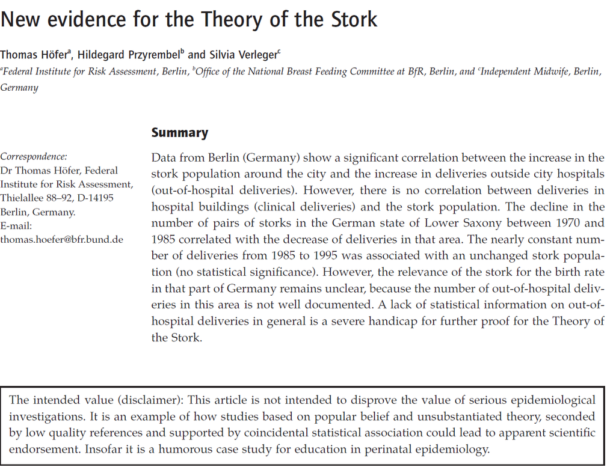

## Positive relationship between the two

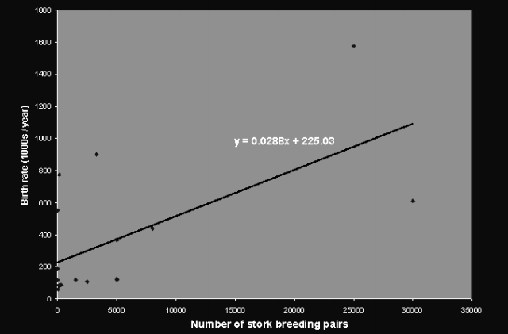

## What is potentially driving the results?

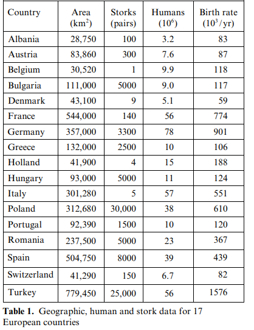

## Do you drown after eating ice cream?

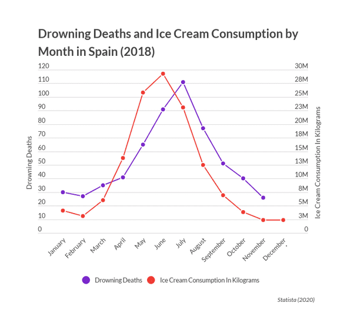

## Internet explorer causes murder?

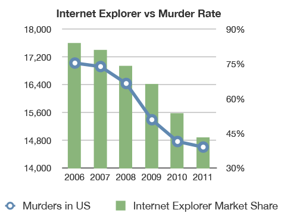

## Learning objectives

- Understand difference between causality and correlation
- Being able to spot omitted variable bias
- Create summary statistics and plots in R using dplyr & ggplot2
- Revisit the basics of linear regression models

## Understanding the effect of price on demand

## Bob’s Ice Cream Business

- Bob bought a small ice cream truck from Emma
- Emma left Bob a small collection of sales data, in which she noted for each day \(t\)
  - the price \(p_{t}\) she had set
  - the number of ice cream portions \(q_{t}\) she had sold
  - the wholesale cost \(w_{t}\) for buying a big box of ice cream
- You are a young consultant who shall help Bob to optimize his ice cream business.
- How would you proceed to find an optimal pricing rule?

## Loading Emma’s data it into R

As a consultant you of course have put Emma’s data into an excel spreadsheet. We load it as follows:

```r
# install.packages("rio")
library("rio")

# import data set using command import from package rio
ice_cream_sales <- import("ice cream sales.csv")

# First have a look at the data, with: Alternative: View(ice_cream_sales)
str(ice_cream_sales)
```

```
## 'data.frame':    200 obs. of  5 variables:
##  $ V1: int  1 2 3 4 5 6 7 8 9 10 ...
##  $ t : int  1 2 3 4 5 6 7 8 9 10 ...
##  $ w : num  31.7 15.6 86.1 98.9 55 ...
##  $ p : num  26.8 26.3 26.1 23.1 27.7 ...
##  $ q : num  53 52.3 50.5 44.2 54.3 ...
```

## Summarize the data using pipe syntax

Pipes ‘%>%’ from package `dplyr’, where in 4 seperate lines

1. we first choose the name of the data set of interest; followed by ‘%>%’ which means ‘then’
2. ‘select(x1,x2,…)’ to choose variables of interest
3. ‘summary()’ to produce summary statistic
4. ‘kable()’ to produce nice tables

## Summary statistics using pipes

```r
library(dplyr)
library(knitr)
library(kableExtra) # extra package to make table fit to slide

ice_cream_sales %>%
select(w,p,q) %>%
summary() %>%
kable()%>%
  kable_styling(full_width = F) # to make table fit to slide
```

|  | w | p | q |
| --- | --- | --- | --- |
|  | Min. : 0.3912 | Min. :21.76 | Min. :42.81 |
|  | 1st Qu.:23.9664 | 1st Qu.:24.46 | 1st Qu.:47.98 |
|  | Median :48.0086 | Median :25.35 | Median :49.74 |
|  | Mean :47.3499 | Mean :25.38 | Mean :49.81 |
|  | 3rd Qu.:70.9175 | 3rd Qu.:26.32 | 3rd Qu.:51.76 |
|  | Max. :99.8161 | Max. :28.31 | Max. :55.56 |

## Intuitive relationship between \(p\) and \(q\)?

As a consultant you know the power of graphs, so you type:

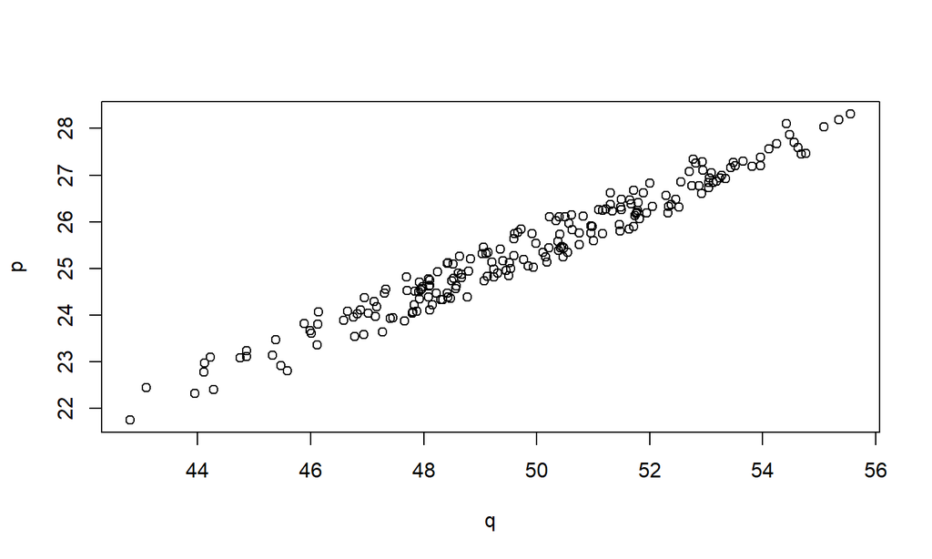

```r
plot(p ~ q, data = ice_cream_sales)
```

Was Emma setting profit-maximizing prices?

## Some explanations

Unobserved factors may increase demand (i.e., demand shocks)

- Advertising may increase demand
- Better quality increase demand
- Seasonality (summer vs winter) likely affects demand

Price may react in response to demand shocks, e.g.,

- ask for higher prices in summer, when demand is high
- ask for lower prices in winter, when demand is low

Unobserved factors affect both demand and price

- which might generate the positive relationship

## The economic model behind omitted variables

## A simple economic theory model

In principle, we can well imagine to have

- a downward-sloping demand function (in price \(p\)),
  - with random demand shocks (e.g., due to seasonality)
- and firms which set profit-maximizing prices

and still find a positive relationship between prices and output.

We now present a simple model of the data generating process

## We first specify the demand function \(q\)

Demand in period \(t\) is given by the following function

\[q_{t}=a_{t}-bp_{t}\]

- \(b>0\): parameter measuring how \(q\) changes with \(p\)
- \(a\) measures how high demand would be at price 0

The market size parameter \(a_{t}\) is given by \[a_{t}=a_{0}+\varepsilon_{t}\]

- \(a_{0}>0\) is a constant (some poeple always buy ice cream)
- \(\varepsilon_{t}\) is a random “demand shock” in period \(t\) (not affected by \(p\)).
  - Good weather: -> higher \(\varepsilon\)

## How do firms set profit-maximizing \(p\)?

The firm’s profits are given by

\[\pi_{t}=p_{t}q_{t}-w_{t}q_{t} - F\]

- \(c_{t}\geq0\) is a constant marginal cost of production in period \(t\) (cost of one portion of ice cream)
- \(F\) are some fixed costs that don’t depend on the price.
- We already know that: \(q_{t}=a_{0}+\varepsilon_{t}-bp_{t}\)

A firm chooses a price \(p_{t}\) that maximizes its profits knowing

- its cost \(w_{t}\),
- the demand shock \(\varepsilon_{t}\)
- the parameters \(a_{0}\) and \(b\)

## Optimal Prices and output

We find optimal prices and quantities are given by:

\[p^*_{t} = \frac{a_0+\varepsilon_t}{2b}+\frac{w_{t}}{2}\] \[q^*_{t} = \frac{a_{0}+\varepsilon_{t}}{2}-\frac{b w_{t}}{2}\]

which both depend on \(a_t=a_0+\epsilon_t\)

(Show this by taking the derivative of profits w.r.t. price \(\frac{\partial \Pi_t}{\partial p_t}\))

## Proof (to look at home)

Plug in demand function into profits

\[\begin{align*} \pi(p_t) & = q_t(p_t)(p-w_{t}) - F\\ & =(a_{t}-bp_t)(p_t-w_{t}) - F\\ & =a_{t}p-a_{t}w_t-bp_t^{2}+bp_tw_{t} - F \end{align*}\]

The first order condition is given by

\[\frac{\partial \pi(p_t)}{\partial p_t} = a_t-2bp_t+bw_t = 0\]

Solving for price \(p\)

\[p_t = \frac{a_{t}}{2b}+\frac{w_{t}}{2}\]

## Proof (to look at home)

If we plug in \(a_t=a_0+\varepsilon_t\), we get \[\begin{align*} p^*_{t} & =\frac{a_{0}+\varepsilon_{t}}{2b}+\frac{w_{t}}{2} \end{align*}\]

Plug this expression into \(q\) to get the equilibrium quantity

\[\begin{align*} q^*_{t} & = a_{0}+\varepsilon_{t} - b p_t^* \\ & = \frac{a_{0}+\varepsilon_{t}}{2}-\frac{b w_{t}}{2} \end{align*}\]

## Simulating the model in R

- To get intuition about this economic model, we want to simulate in R.
- Here and in other places I will show you some R code in the class and the steps are roughly described in the slides.
- You will repeat similar steps in more detail in the corresponding RTutor problem sets (here the problem set for Chapter 1a).
  - For that reason you won’t get the R code from class. Look at the RTutor problem set instead.

```r
T = 10 # number of days
a0 = 100 # market size parameter
b = 1
c = runif(T,min = 10, max = 20)

sigma.eps = 10 # standard deviation sigma of demand shocks
eps = rnorm(n = T, mean = 0, sd = sigma.eps)

# equation for optimal prices
p = (a0 + eps)/(2*b)  + c / 2

# demand function
q = a0 + eps - b*p
```

## Plot the graph

Indeed we have a positive relationship between \(p\) and \(q\)

- although demand is downward sloping due to \(b=1\)
- \(b=1\) enters negatively into the demand function

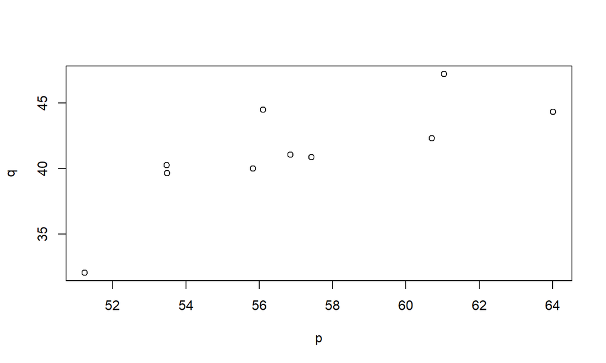

The reason is that

- positive epsilons increase both the \(p\) and the \(q\)
- while negative epsilons decrease both the \(p\) and the \(q\).

To do at home

- Set T=1000 to see a stronger relationship
- Decrease epsilon to 0.0001 to see the role demand shock on the relationship between \(p\) and \(q\)
- How does the relationship change between \(p\) and \(q\)?
- What is the slope of demand function?

## Estimating the demand function

- Use the R function lm (stands for linear model) to estimate the following linear regression model of the demand function

\[\begin{align*} q_{t}=&\beta_{0}&+&\beta_{1}p_{t}&+\varepsilon_{t} \\ (=& a_0 &+& (-b)p_t & +\varepsilon_{t}) \end{align*}\]

## via ordinary least squares (OLS).

```r
T=1000
lm(q~p)
```

```
##
## Call:
## lm(formula = q ~ p)
##
## Coefficients:
## (Intercept)            p
##     -3.7501       0.7889
```

And of course, we get inconsistent estimates representing the upward sloping relationship from the previous graph.

Let’s replace p with random values and calculate corresponding quantity for high T. Remember that \(a_0=100\) and \(b=1\)

```r
T = 10000
p = runif(n=T,min = 30,max = 50)
q = a0 + eps - b*p

lm(q ~ p)
```

```
##
## Call:
## lm(formula = q ~ p)
##
## Coefficients:
## (Intercept)            p
##       98.26        -1.00
```

Are we close to the true values? Justify why resp. why not.

Given that prices are randomly drawn, they do not depend on demand shock \(a\) and we do not have an omitted variable problem. Thus, the effect of \(p\) on \(q\) is just \(a_0=100\) and \(b=-1\).As intuitively seen by looking at the demand function.

## Reduce number of observatins to T=10

```r
T = 10
p = runif(n=T,min = 30,max = 50)
q = a0 + eps - b*p

lm(q ~ p)
```

```
##
## Call:
## lm(formula = q ~ p)
##
## Coefficients:
## (Intercept)            p
##     122.082       -1.584
```

The estimates seem to be closer to the true values when the number of observations is high. This is known as consistency.

## What have we done so far?

- **Policy Question:** We want to find a rule to set profit maximizing prices for Bob’s ice cream business.
- **Model for decision:** To find optimal prices, we need to know / estimate a demand function for ice cream.
- **Data:** We got a historical data set of prices and output.
- **Findings:** Interestingly, prices are positively correlated with quantity sold.
  - Importantly, there are also random demand shocks \(u\) (incorporating conditions like weather) that have been known by the price setter.